# Final Insight and Analysis Exploration

Candidate supporting analyses for Singapore fertility story

Author

Team 11

## Purpose

This notebook creates supporting plots for the final presentation. The goal is not to treat every plot as a separate insight. The team can combine plots where one insight needs more than one view.

Recommended final choice for now:

1. Policy context: TFR around major fertility policies and before-vs-after comparison
2. Delayed family formation: LFPR/singlehood bubble scatter and ASFR decade heatmap
3. Smaller completed family size: family-size trend among ever-married women aged 40 to 49 and survey reasons for not wanting children or more children

The recession event-window plot was removed from the main flow because it gives a weaker and less consistent explanation of the long-term fertility decline. Recession can remain as a contextual annotation in the final visual if needed.

## 1. Setup

```r
library(tidyverse)
library(broom)
library(patchwork)
```

## 2. Read and clean the local datasets

```r
data_dir <- file.path("proposal_files", "datasets")

fertility_file <- file.path(data_dir, "BirthsAndFertilityRatesAnnual.csv")
singlehood_file <- file.path(data_dir, "M810581.csv")
lfpr_file <- file.path(data_dir, "M182201.csv")
family_size_file <- "ResidentEverMarriedFemalesByAgeGroupAndNumberOfChildrenBornAnnual.csv"
birth_order_file <- "LiveBirthsByBirthOrderAnnual.csv"

tibble(
  dataset = c(
    "Births and fertility",
    "Singlehood",
    "Female LFPR",
    "Ever-married females by children born",
    "Live births by birth order"
  ),
  file_path = c(
    fertility_file,
    singlehood_file,
    lfpr_file,
    family_size_file,
    birth_order_file
  ),
  file_exists = file.exists(c(
    fertility_file,
    singlehood_file,
    lfpr_file,
    family_size_file,
    birth_order_file
  ))
)
```

```
# A tibble: 5 × 3
  dataset                               file_path                    file_exists
  <chr>                                 <chr>                        <lgl>
1 Births and fertility                  proposal_files/datasets/Bir… TRUE
2 Singlehood                            proposal_files/datasets/M81… TRUE
3 Female LFPR                           proposal_files/datasets/M18… TRUE
4 Ever-married females by children born ResidentEverMarriedFemalesB… TRUE
5 Live births by birth order            LiveBirthsByBirthOrderAnnua… FALSE
```

```r
read_singstat_wide <- function(path) {
  lines <- readLines(path, warn = FALSE)
  header_index <- which(stringr::str_detect(lines, "^Data\\s*Series\\s*,"))[1]

  if (is.na(header_index)) {
    stop("Could not find a 'Data Series' or 'DataSeries' header in: ", path)
  }

  raw_data <- readr::read_csv(
    path,
    skip = header_index - 1,
    na = c("", "na", "NA", "N.A.", "-"),
    show_col_types = FALSE
  ) |>
    rename_with(trimws)

  names(raw_data)[1] <- "data_series"

  raw_data |>
    mutate(
      row_id = row_number(),
      data_series_raw = data_series,
      data_series = stringr::str_squish(data_series)
    ) |>
    filter(!is.na(data_series), data_series != "")
}

to_long_years <- function(data) {
  year_cols <- names(data)[stringr::str_detect(names(data), "^\\d{4}$")]

  data |>
    pivot_longer(
      cols = all_of(year_cols),
      names_to = "year",
      values_to = "value"
    ) |>
    mutate(
      year = as.integer(year),
      value = readr::parse_number(as.character(value))
    ) |>
    filter(!is.na(year))
}

standardise_age_group <- function(x) {
  x |>
    stringr::str_squish() |>
    stringr::str_replace_all("\\s*-\\s*", "-")
}

is_age_group <- function(x) {
  stringr::str_detect(
    x,
    "^\\d{2}\\s*-\\s*\\d{2}\\s*Years$|^\\d{2}\\s*Years & Over$|^\\d{2}\\s*Years And Over$"
  )
}
```

```r
asfr_age_groups <- c(
  "15-19 Years",
  "20-24 Years",
  "25-29 Years",
  "30-34 Years",
  "35-39 Years",
  "40-44 Years",
  "45-49 Years"
)

driver_age_groups <- c(
  "25-29 Years",
  "30-34 Years",
  "35-39 Years",
  "40-44 Years",
  "45-49 Years"
)

age_palette <- c(
  "15-19 Years" = "#4C78A8",
  "20-24 Years" = "#F28E5C",
  "25-29 Years" = "#F2D98D",
  "30-34 Years" = "#FFF8B5",
  "35-39 Years" = "#DDEB8C",
  "40-44 Years" = "#A7D39A",
  "45-49 Years" = "#C94B55"
)

children_born_levels <- c(
  "None",
  "1 Child",
  "2 Children",
  "3 Children",
  "4 Or More Children"
)

children_born_palette <- c(
  "None" = "#6B7280",
  "1 Child" = "#7BC8A4",
  "2 Children" = "#F2D98D",
  "3 Children" = "#F28E5C",
  "4 Or More Children" = "#C94B55"
)
```

## 3. Build analysis-ready tables

```r
fertility_wide <- read_singstat_wide(fertility_file)

tfr_annual <- fertility_wide |>
  filter(data_series == "Total Fertility Rate (TFR)") |>
  to_long_years() |>
  transmute(year, tfr = value)

asfr_by_age <- fertility_wide |>
  mutate(age_group = standardise_age_group(data_series)) |>
  filter(age_group %in% asfr_age_groups) |>
  to_long_years() |>
  transmute(
    year,
    age_group = factor(age_group, levels = asfr_age_groups),
    asfr = value
  ) |>
  arrange(year, age_group)
```

```r
singlehood_wide <- read_singstat_wide(singlehood_file)

singlehood_tagged <- singlehood_wide |>
  mutate(
    age_group = if_else(
      is_age_group(data_series),
      standardise_age_group(data_series),
      NA_character_
    ),
    sex = case_when(
      data_series == "Males" ~ "Male",
      data_series == "Females" ~ "Female",
      TRUE ~ "Total"
    )
  ) |>
  tidyr::fill(age_group, .direction = "down")

singlehood_female_by_age <- singlehood_tagged |>
  filter(sex == "Female", age_group %in% driver_age_groups) |>
  to_long_years() |>
  transmute(
    year,
    age_group = factor(age_group, levels = driver_age_groups),
    single_female_pct = value
  ) |>
  arrange(year, age_group)

singlehood_female_25_49 <- singlehood_female_by_age |>
  group_by(year) |>
  summarise(
    single_female_25_49_pct = mean(single_female_pct, na.rm = TRUE),
    .groups = "drop"
  )
```

```r
lfpr_wide <- read_singstat_wide(lfpr_file)

lfpr_tagged <- lfpr_wide |>
  mutate(
    sex_section = case_when(
      data_series == "Total Resident Participation Rate" ~ "Total",
      data_series == "Male Resident Participation Rate" ~ "Male",
      data_series == "Female Resident Participation Rate" ~ "Female",
      TRUE ~ NA_character_
    ),
    age_group = if_else(
      is_age_group(data_series),
      standardise_age_group(data_series),
      NA_character_
    )
  ) |>
  tidyr::fill(sex_section, .direction = "down")

lfpr_female_by_age <- lfpr_tagged |>
  filter(sex_section == "Female", age_group %in% driver_age_groups) |>
  to_long_years() |>
  transmute(
    year,
    age_group = factor(age_group, levels = driver_age_groups),
    female_lfpr_pct = value
  ) |>
  arrange(year, age_group)

lfpr_female_25_49 <- lfpr_female_by_age |>
  group_by(year) |>
  summarise(
    female_lfpr_25_49_pct = mean(female_lfpr_pct, na.rm = TRUE),
    .groups = "drop"
  )
```

```r
annual_drivers <- tibble(year = 1960:2025) |>
  left_join(tfr_annual, by = "year") |>
  left_join(singlehood_female_25_49, by = "year") |>
  left_join(lfpr_female_25_49, by = "year") |>
  mutate(
    decade = paste0(floor(year / 10) * 10, "s")
  )

annual_drivers |>
  summarise(
    min_year = min(year),
    max_year = max(year),
    tfr_available = sum(!is.na(tfr)),
    singlehood_available = sum(!is.na(single_female_25_49_pct)),
    lfpr_available = sum(!is.na(female_lfpr_25_49_pct))
  )
```

```
# A tibble: 1 × 5
  min_year max_year tfr_available singlehood_available lfpr_available
     <int>    <int>         <int>                <int>          <int>
1     1960     2025            66                   43             36
```

```r
family_size_wide <- read_singstat_wide(family_size_file)

family_size_tagged <- family_size_wide |>
  mutate(
    age_group = if_else(
      is_age_group(data_series),
      standardise_age_group(data_series),
      NA_character_
    ),
    children_born = if_else(
      data_series %in% c("None", "1 Child", "2 Children", "3 Children", "4 Or More Children"),
      data_series,
      NA_character_
    )
  ) |>
  tidyr::fill(age_group, .direction = "down")

family_size_40_49 <- family_size_tagged |>
  filter(age_group == "40-49 Years", children_born %in% children_born_levels) |>
  to_long_years() |>
  transmute(
    year,
    children_born = factor(children_born, levels = children_born_levels),
    females = value
  ) |>
  group_by(year) |>
  mutate(
    total_females = sum(females, na.rm = TRUE),
    share_pct = females / total_females * 100
  ) |>
  ungroup() |>
  arrange(year, children_born)

family_size_40_49 |>
  summarise(
    first_year = min(year),
    latest_year = max(year),
    rows = n(),
    categories = n_distinct(children_born)
  )
```

```
# A tibble: 1 × 4
  first_year latest_year  rows categories
       <int>       <int> <int>      <int>
1       1980        2025   210          5
```

```r
# Midpoint of each five-year age band, used to weight the mean age of childbearing.
asfr_midpoints <- tibble(
  age_group = factor(asfr_age_groups, levels = asfr_age_groups),
  midpoint  = c(17.5, 22.5, 27.5, 32.5, 37.5, 42.5, 47.5)
)

# The 45-49 row is missing before 1980. Its ASFR is under 1 per 1,000 in every year
# where it does exist, so we treat it as zero and verify below that this creates no break.
asfr_complete <- asfr_by_age |>
  mutate(asfr = coalesce(asfr, 0)) |>
  left_join(asfr_midpoints, by = "age_group")
```

### Validation checks

```r
# Check 1: rebuilding TFR from the age-specific rates should reproduce the published TFR.
# TFR = 5 * sum(ASFR) / 1000, because each band spans five single years of age.
tfr_reconstruction <- asfr_complete |>
  group_by(year) |>
  summarise(tfr_rebuilt = sum(asfr) * 5 / 1000, .groups = "drop") |>
  left_join(tfr_annual, by = "year") |>
  mutate(difference = tfr_rebuilt - tfr)

tfr_reconstruction |>
  summarise(
    years_checked  = n(),
    max_abs_diff   = max(abs(difference), na.rm = TRUE),
    mean_abs_diff  = mean(abs(difference), na.rm = TRUE)
  )
```

```
# A tibble: 1 × 3
  years_checked max_abs_diff mean_abs_diff
          <int>        <dbl>         <dbl>
1            66      0.00550       0.00259
```

```r
# Check 2: the 45-49 band is missing before 1980 and treated as zero.
# Confirm this creates no break in the mean age of childbearing at the 1979/1980 boundary.
asfr_complete |>
  filter(year %in% 1976:1983) |>
  group_by(year) |>
  summarise(mac = sum(midpoint * asfr) / sum(asfr), .groups = "drop") |>
  mutate(year_on_year_change = round(mac - lag(mac), 4))
```

```
# A tibble: 8 × 3
   year   mac year_on_year_change
  <int> <dbl>               <dbl>
1  1976  28.1             NA
2  1977  28.1              0.0638
3  1978  28.1              0.0021
4  1979  28.2              0.0901
5  1980  28.2             -0.0016
6  1981  28.2              0.0183
7  1982  28.4              0.107
8  1983  28.4              0.0526
```

## 4. Insight 1: did fertility policies visibly change the TFR trend?

### Why this is useful

For the final insight section, it is clearer to show what happened to TFR before and after each major policy.

This section uses two policy-focused plots:

1. Actual TFR around each policy year
2. Five-year before-vs-after average TFR change

Definitions:

- Anti-natalist means policy that discourages higher fertility. Example: Stop at Two.
- Pro-natalist means policy that encourages higher fertility. Examples: Have Three or More, Baby Bonus, Marriage and Parenthood package.
- These plots show timing and association. They do not prove direct causality.

```r
policy_events <- tribble(
  ~event_year, ~event_label, ~policy_stance,
  1972, "Stop at Two", "Anti-natalist",
  1987, "Have Three or More", "Pro-natalist",
  2001, "Baby Bonus", "Pro-natalist",
  2013, "Marriage and Parenthood package", "Pro-natalist"
)

policy_window <- policy_events |>
  crossing(relative_year = -5:10) |>
  mutate(year = event_year + relative_year) |>
  left_join(tfr_annual, by = "year") |>
  group_by(event_year, event_label, policy_stance) |>
  mutate(
    event_tfr = tfr[relative_year == 0][1],
    tfr_change_from_event = tfr - event_tfr,
    event_label = factor(
      event_label,
      levels = c("Stop at Two", "Have Three or More", "Baby Bonus", "Marriage and Parenthood package")
    )
  ) |>
  ungroup()

policy_window |>
  filter(relative_year %in% c(-5, 0, 5, 10)) |>
  select(event_label, policy_stance, relative_year, year, tfr, tfr_change_from_event)
```

```
# A tibble: 16 × 6
   event_label     policy_stance relative_year  year   tfr tfr_change_from_event
   <fct>           <chr>                 <int> <dbl> <dbl>                 <dbl>
 1 Stop at Two     Anti-natalist            -5  1967  3.91                0.87
 2 Stop at Two     Anti-natalist             0  1972  3.04                0
 3 Stop at Two     Anti-natalist             5  1977  1.82               -1.22
 4 Stop at Two     Anti-natalist            10  1982  1.74               -1.3
 5 Have Three or … Pro-natalist             -5  1982  1.74                0.120
 6 Have Three or … Pro-natalist              0  1987  1.62                0
 7 Have Three or … Pro-natalist              5  1992  1.72                0.1000
 8 Have Three or … Pro-natalist             10  1997  1.61               -0.0100
 9 Baby Bonus      Pro-natalist             -5  1996  1.66                0.250
10 Baby Bonus      Pro-natalist              0  2001  1.41                0
11 Baby Bonus      Pro-natalist              5  2006  1.28               -0.130
12 Baby Bonus      Pro-natalist             10  2011  1.2                -0.21
13 Marriage and P… Pro-natalist             -5  2008  1.28                0.0900
14 Marriage and P… Pro-natalist              0  2013  1.19                0
15 Marriage and P… Pro-natalist              5  2018  1.14               -0.0500
16 Marriage and P… Pro-natalist             10  2023  0.97               -0.220
```

### Plot 1A: actual TFR before and after each policy

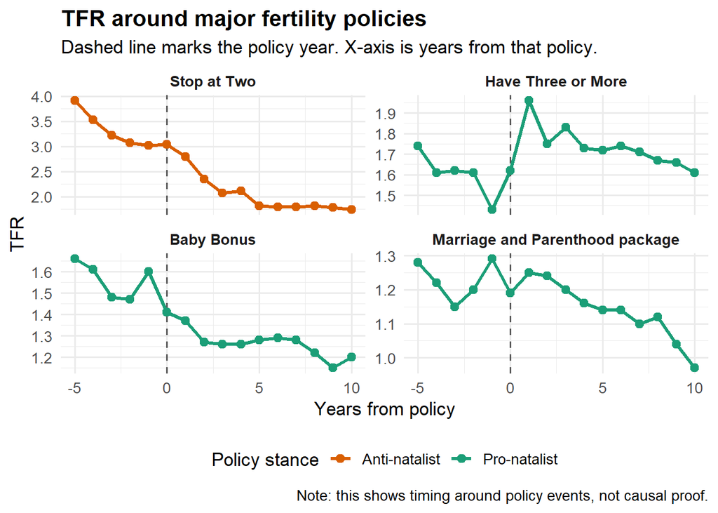

```r
ggplot(policy_window, aes(x = relative_year, y = tfr, colour = policy_stance)) +
  geom_vline(xintercept = 0, linetype = "dashed", colour = "grey35") +
  geom_line(linewidth = 1.1) +
  geom_point(size = 2.4) +
  facet_wrap(~ event_label, scales = "free_y", ncol = 2) +
  scale_colour_manual(
    values = c(
      "Anti-natalist" = "#d95f02",
      "Pro-natalist" = "#1b9e77"
    )
  ) +
  scale_x_continuous(breaks = c(-5, 0, 5, 10)) +
  labs(
    title = "TFR around major fertility policies",
    subtitle = "Dashed line marks the policy year. X-axis is years from that policy.",
    x = "Years from policy",
    y = "TFR",
    colour = "Policy stance",
    caption = "Note: this shows timing around policy events, not causal proof."
  ) +
  theme_minimal(base_size = 13) +
  theme(
    legend.position = "bottom",
    plot.title = element_text(face = "bold"),
    strip.text = element_text(face = "bold")
  )
```

### Plot 1B: five-year before-vs-after policy dumbbell comparison

```r
policy_before_after <- policy_events |>
  mutate(
    before_years = map(event_year, ~ (.x - 5):(.x - 1)),
    after_years = map(event_year, ~ (.x + 1):(.x + 5))
  ) |>
  unnest_longer(before_years, values_to = "before_year") |>
  left_join(tfr_annual |> rename(before_tfr = tfr), by = c("before_year" = "year")) |>
  group_by(event_year, event_label, policy_stance) |>
  summarise(before_mean_tfr = mean(before_tfr, na.rm = TRUE), .groups = "drop") |>
  left_join(
    policy_events |>
      mutate(after_years = map(event_year, ~ (.x + 1):(.x + 5))) |>
      unnest_longer(after_years, values_to = "after_year") |>
      left_join(tfr_annual |> rename(after_tfr = tfr), by = c("after_year" = "year")) |>
      group_by(event_year, event_label, policy_stance) |>
      summarise(after_mean_tfr = mean(after_tfr, na.rm = TRUE), .groups = "drop"),
    by = c("event_year", "event_label", "policy_stance")
  ) |>
  mutate(
    five_year_change = after_mean_tfr - before_mean_tfr,
    change_direction = if_else(five_year_change >= 0, "Higher after policy", "Lower after policy"),
    change_label = paste0(if_else(five_year_change >= 0, "+", ""), sprintf("%.2f", five_year_change)),
    label_x = pmax(before_mean_tfr, after_mean_tfr) + 0.05,
    event_label = factor(
      event_label,
      levels = rev(c("Stop at Two", "Have Three or More", "Baby Bonus", "Marriage and Parenthood package"))
    )
  )

policy_before_after
```

```
# A tibble: 4 × 9
  event_year event_label            policy_stance before_mean_tfr after_mean_tfr
       <dbl> <fct>                  <chr>                   <dbl>          <dbl>
1       1972 Stop at Two            Anti-natalist            3.35           2.23
2       1987 Have Three or More     Pro-natalist             1.60           1.80
3       2001 Baby Bonus             Pro-natalist             1.56           1.29
4       2013 Marriage and Parentho… Pro-natalist             1.23           1.20
# ℹ 4 more variables: five_year_change <dbl>, change_direction <chr>,
#   change_label <chr>, label_x <dbl>
```

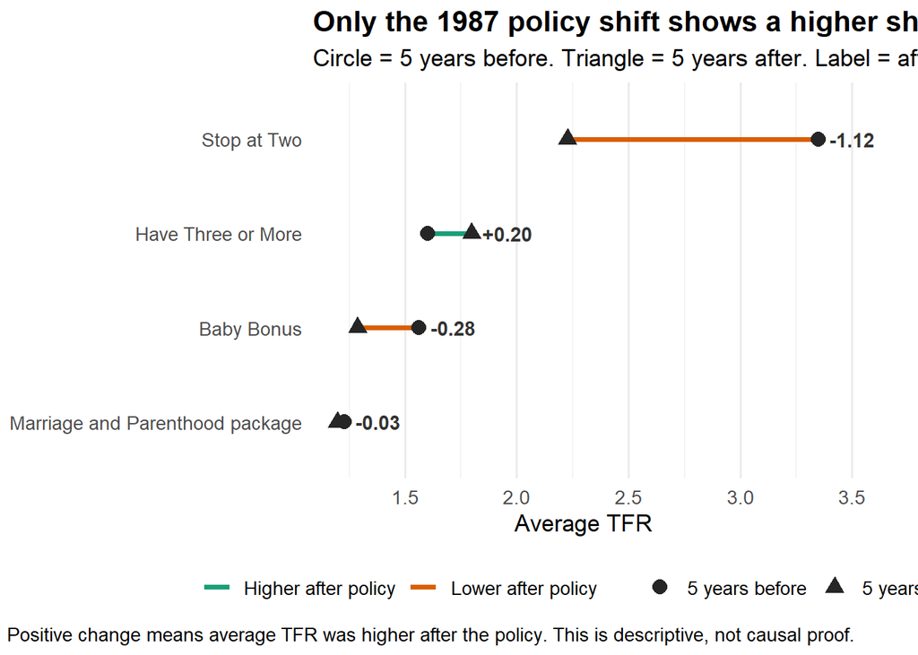

```r
policy_before_after_long <- policy_before_after |>
  select(event_label, policy_stance, before_mean_tfr, after_mean_tfr, five_year_change, change_label, label_x) |>
  pivot_longer(
    cols = c(before_mean_tfr, after_mean_tfr),
    names_to = "period",
    values_to = "mean_tfr"
  ) |>
  mutate(
    period = recode(
      period,
      before_mean_tfr = "5 years before",
      after_mean_tfr = "5 years after"
    ),
    period = factor(period, levels = c("5 years before", "5 years after"))
  )

ggplot(policy_before_after, aes(y = event_label)) +
  geom_segment(
    aes(x = before_mean_tfr, xend = after_mean_tfr, yend = event_label, colour = change_direction),
    linewidth = 1.3
  ) +
  geom_point(
    data = policy_before_after_long,
    aes(x = mean_tfr, shape = period),
    size = 3.4,
    colour = "grey15"
  ) +
  geom_text(
    aes(x = label_x, label = change_label),
    hjust = 0,
    colour = "grey20",
    size = 3.8,
    fontface = "bold"
  ) +
  scale_colour_manual(
    values = c(
      "Higher after policy" = "#1b9e77",
      "Lower after policy" = "#d95f02"
    )
  ) +
  coord_cartesian(clip = "off") +
  labs(
    title = "Only the 1987 policy shift shows a higher short-term average TFR",
    subtitle = "Circle = 5 years before. Triangle = 5 years after. Label = after minus before.",
    x = "Average TFR",
    y = NULL,
    colour = NULL,
    shape = NULL,
    caption = "Positive change means average TFR was higher after the policy. This is descriptive, not causal proof."
  ) +
  theme_minimal(base_size = 13) +
  theme(
    legend.position = "bottom",
    panel.grid.major.y = element_blank(),
    plot.title = element_text(face = "bold"),
    plot.margin = margin(5.5, 35, 5.5, 5.5)
  )
```

### Detailed analysis for understanding

- This policy insight asks a more direct question: after a major fertility policy, did TFR visibly rise, fall, or stay flat?
- The anti-natalist Stop at Two period is followed by continued decline. This fits the historical context because the policy direction was to reduce fertility.
- The 1987 pro-natalist shift is the only policy point in this comparison where the five-year after average is higher than the five-year before average. This suggests a short-term improvement or stabilisation after the policy reversal.
- However, the later pro-natalist policies do not show the same clear rebound. Baby Bonus and the Marriage and Parenthood package happen when TFR is already low, and the after-policy average does not show a strong recovery.
- This does not mean those policies failed completely. They may have slowed decline, supported families, or prevented an even lower TFR. The plot only shows that they did not create a large sustained increase in TFR.
- Main interpretation: policy matters, but policy alone does not explain Singapore’s fertility trend. Earlier anti-natalist policy aligns with fertility reduction, while later pro-natalist policies appear unable to fully reverse deeper social and demographic changes.

## 5. Insight 2: delayed family formation

### Why this is useful

This insight combines two related views instead of treating them as separate findings.

The first view shows the outcome: childbearing has shifted from younger age groups toward older age groups. The second view shows the wider social context: lower fertility happened alongside higher female labour-force participation and higher singlehood.

This should be framed carefully. The point is not that women working directly caused fertility to fall. The safer interpretation is that fertility decline developed together with broader changes in education, work, marriage timing, and family formation.

### Plot 2A: ASFR decade heatmap

```r
asfr_decade <- asfr_by_age |>
  mutate(
    decade_start = floor(year / 10) * 10,
    decade = case_when(
      decade_start == 2020 ~ "2020s",
      TRUE ~ paste0(decade_start, "s")
    )
  ) |>
  group_by(decade, age_group) |>
  summarise(mean_asfr = mean(asfr, na.rm = TRUE), .groups = "drop") |>
  mutate(
    decade = factor(decade, levels = c("1960s", "1970s", "1980s", "1990s", "2000s", "2010s", "2020s")),
    label_asfr = if_else(is.na(mean_asfr), "", as.character(round(mean_asfr, 0)))
  )

asfr_decade |>
  arrange(decade, age_group)
```

```
# A tibble: 49 × 4
   decade age_group   mean_asfr label_asfr
   <fct>  <fct>           <dbl> <chr>
 1 1960s  15-19 Years      43.2 "43"
 2 1960s  20-24 Years     218.  "218"
 3 1960s  25-29 Years     272.  "272"
 4 1960s  30-34 Years     206.  "206"
 5 1960s  35-39 Years     132.  "132"
 6 1960s  40-44 Years      54.2 "54"
 7 1960s  45-49 Years     NaN   ""
 8 1970s  15-19 Years      19.1 "19"
 9 1970s  20-24 Years     114.  "114"
10 1970s  25-29 Years     174.  "174"
# ℹ 39 more rows
```

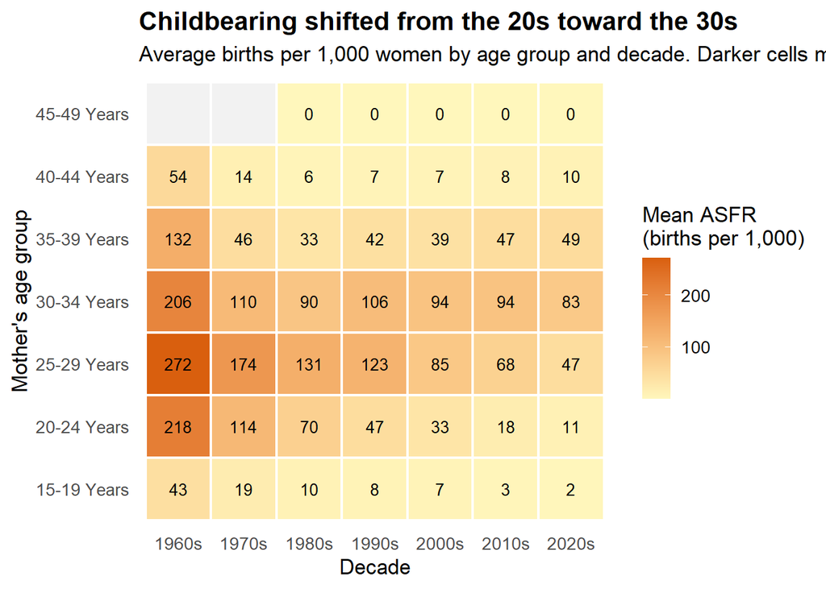

```r
ggplot(asfr_decade, aes(x = decade, y = age_group, fill = mean_asfr)) +
  geom_tile(colour = "white", linewidth = 0.8) +
  geom_text(aes(label = label_asfr), size = 3.6) +
  scale_fill_gradient(low = "#fff7bc", high = "#d95f0e", na.value = "grey95") +
  labs(
    title = "Childbearing shifted from the 20s toward the 30s",
    subtitle = "Average births per 1,000 women by age group and decade. Darker cells mean higher fertility intensity.",
    x = "Decade",
    y = "Mother's age group",
    fill = "Mean ASFR\n(births per 1,000)"
  ) +
  theme_minimal(base_size = 13) +
  theme(
    legend.position = "right",
    panel.grid = element_blank(),
    plot.title = element_text(face = "bold"),
    axis.text.x = element_text(angle = 0, hjust = 0.5)
  )
```

### Detailed analysis for understanding

- The heatmap shows fertility intensity by age group and decade. Darker cells mean that age group had more births per 1,000 women.
- In the 1960s, fertility was high across several younger age groups. The strongest group was 25 to 29, with mean ASFR around 272.
- The 20 to 24 group was also very high in the 1960s, around 218. By the 2020s, it fell to around 11. This is one of the clearest signs that younger childbearing has collapsed.
- The 25 to 29 group also fell strongly, from around 272 in the 1960s to around 47 in the 2020s.
- The 30 to 34 group also declined in absolute terms, but it became the highest recent age group. In other words, fertility fell overall, but the centre of childbearing shifted older.
- The 35 to 39 group became relatively more important in recent decades. This supports the idea that more childbearing is happening later.
- Main interpretation: Singapore’s fertility decline is not only a drop in the number of children women have. It is also a timing shift, where births are delayed from the 20s toward the 30s.
- Why this matters: if first births happen later, there is less time for second or third births. This can help explain why TFR remains low even if some women still eventually have children.

### Plot 2B: work and marriage context

### Why this is useful

This plot adds context to the ASFR heatmap. If the heatmap shows that childbearing moved later, the bubble plot shows that this happened during a period when female labour-force participation and singlehood were also rising.

This should be framed carefully. The plot does not mean women working causes fertility to fall. It shows that lower fertility happened alongside changes in work and marriage patterns.

```r
bubble_data <- annual_drivers |>
  filter(
    !is.na(tfr),
    !is.na(single_female_25_49_pct),
    !is.na(female_lfpr_25_49_pct)
  ) |>
  mutate(
    decade = factor(decade),
    label_year = case_when(
      year == min(year) ~ paste0(year, " start"),
      year == max(year) ~ paste0(year, " latest"),
      TRUE ~ NA_character_
    )
  )

bubble_data |>
  summarise(
    first_year = min(year),
    last_year = max(year),
    tfr_first = tfr[which.min(year)],
    tfr_last = tfr[which.max(year)],
    singlehood_first = single_female_25_49_pct[which.min(year)],
    singlehood_last = single_female_25_49_pct[which.max(year)],
    lfpr_first = female_lfpr_25_49_pct[which.min(year)],
    lfpr_last = female_lfpr_25_49_pct[which.max(year)]
  )
```

```
# A tibble: 1 × 8
  first_year last_year tfr_first tfr_last singlehood_first singlehood_last
       <int>     <int>     <dbl>    <dbl>            <dbl>           <dbl>
1       1990      2024      1.83     0.97             18.8            31.5
# ℹ 2 more variables: lfpr_first <dbl>, lfpr_last <dbl>
```

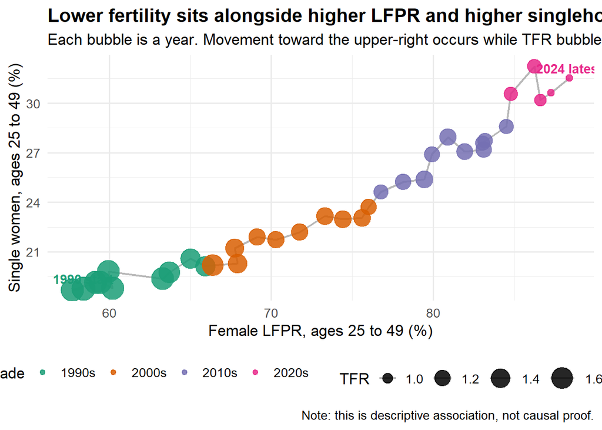

```r
ggplot(
  bubble_data,
  aes(
    x = female_lfpr_25_49_pct,
    y = single_female_25_49_pct,
    size = tfr,
    colour = decade
  )
) +
  geom_path(aes(group = 1), colour = "grey65", linewidth = 0.8, alpha = 0.8) +
  geom_point(alpha = 0.85) +
  geom_text(
    data = bubble_data |> filter(!is.na(label_year)),
    aes(label = label_year),
    nudge_y = 0.6,
    size = 3.8,
    fontface = "bold",
    show.legend = FALSE
  ) +
  scale_size_continuous(range = c(2.5, 9)) +
  scale_colour_brewer(palette = "Dark2") +
  labs(
    title = "Lower fertility sits alongside higher LFPR and higher singlehood",
    subtitle = "Each bubble is a year. Movement toward the upper-right occurs while TFR bubbles get smaller.",
    x = "Female LFPR, ages 25 to 49 (%)",
    y = "Single women, ages 25 to 49 (%)",
    size = "TFR",
    colour = "Decade",
    caption = "Note: this is descriptive association, not causal proof."
  ) +
  theme_minimal(base_size = 13) +
  theme(
    legend.position = "bottom",
    plot.title = element_text(face = "bold")
  )
```

```r
driver_correlations <- bubble_data |>
  summarise(
    correlation_lfpr_tfr = cor(female_lfpr_25_49_pct, tfr, use = "complete.obs"),
    correlation_singlehood_tfr = cor(single_female_25_49_pct, tfr, use = "complete.obs")
  )

driver_correlations
```

```
# A tibble: 1 × 2
  correlation_lfpr_tfr correlation_singlehood_tfr
                 <dbl>                      <dbl>
1               -0.946                     -0.886
```

### Combined analysis for understanding

- Each bubble represents one year.
- The x-axis shows female labour-force participation, ages 25 to 49.
- The y-axis shows the percentage of single women, ages 25 to 49.
- Bubble size represents TFR. Larger bubbles mean higher TFR. Smaller bubbles mean lower TFR.
- Over time, the points move from the lower-left to the upper-right. This means female LFPR and female singlehood both increased.
- At the same time, the bubbles become smaller. This means TFR declined while LFPR and singlehood rose.
- This supports a social-context explanation: fertility decline is linked to later or less frequent family formation.
- A likely mechanism is that higher education and work participation can change life priorities and timing. If marriage happens later, first birth may also happen later. If first birth happens later, there is less time for larger families.
- The singlehood variable is especially important in Singapore’s context because marriage and childbearing are closely connected. Higher singlehood at ages 25 to 49 means fewer women are in the typical married-parenthood pathway during those years.
- The descriptive correlations are strongly negative in this dataset: about -0.95 for LFPR and TFR, and about -0.89 for singlehood and TFR.
- Interpretation caution: correlation is not causality. This plot does not prove that LFPR or singlehood directly caused lower fertility. It shows that low fertility developed alongside broader changes in work and marriage patterns.
- The ASFR heatmap strengthens this insight because it shows the actual fertility timing shift. Fertility in the 20 to 24 and 25 to 29 age groups fell sharply, while the 30 to 34 age group became the main recent childbearing age group.
- Main interpretation: policy alone cannot fully explain persistent low fertility. Social changes in work and marriage help explain why TFR remained low even after Singapore shifted toward pro-natalist policy, because family formation is happening later and the window for having multiple children becomes shorter.

## 6. Insight 3: smaller family size among ever-married women

### Why this is useful

Insight 2 explains delayed family formation. Insight 3 answers a different question: after women marry, are family sizes also becoming smaller, and what practical constraints may help explain this?

This section uses two supporting plots:

1. A family-size trend among ever-married women aged 40 to 49. This shows the outcome.
2. Survey reasons from the 2021 Marriage and Parenthood Survey. This gives context for why married respondents may not want children or more children.

The family-size dataset is stronger than birth-order data for this specific insight because it looks at ever-married women and the number of children they have had. The clearest group to focus on is women aged 40 to 49, because they are closer to the end of their childbearing years. This makes the family-size interpretation more defensible.

### Plot 3A: family-size trend among ever-married women aged 40 to 49

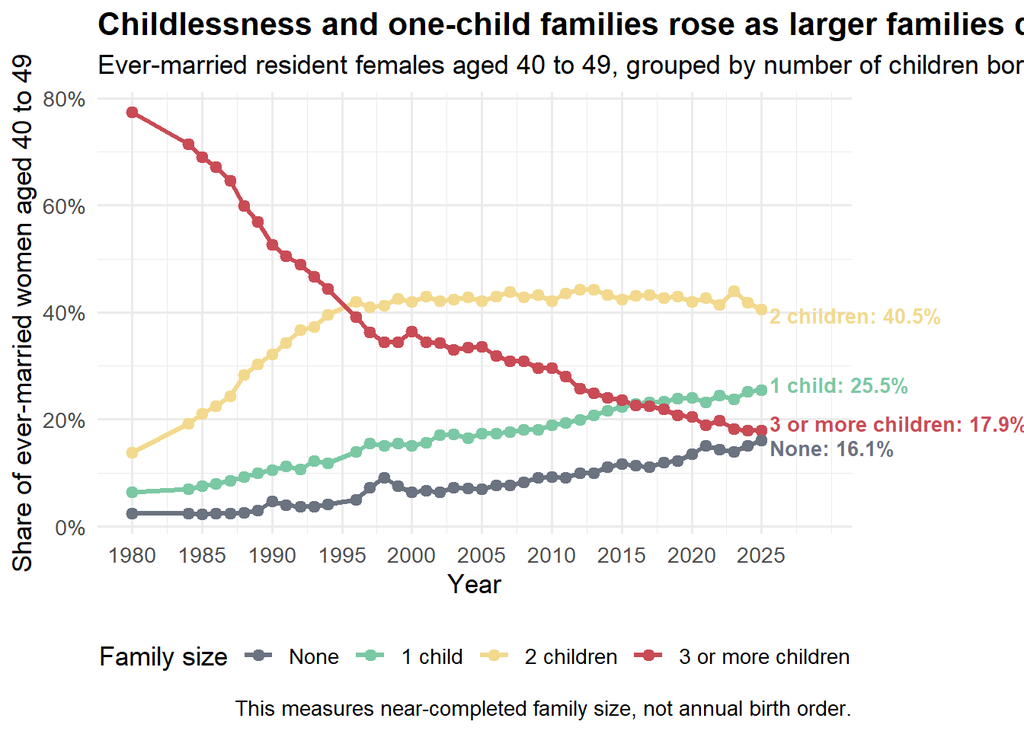

```r
family_size_summary <- family_size_40_49 |>
  mutate(
    family_size_group = case_when(
      children_born == "None" ~ "None",
      children_born == "1 Child" ~ "1 child",
      children_born == "2 Children" ~ "2 children",
      children_born %in% c("3 Children", "4 Or More Children") ~ "3 or more children",
      TRUE ~ NA_character_
    )
  ) |>
  filter(!is.na(family_size_group)) |>
  group_by(year, family_size_group) |>
  summarise(share_pct = sum(share_pct, na.rm = TRUE), .groups = "drop") |>
  mutate(
    family_size_group = factor(
      family_size_group,
      levels = c("None", "1 child", "2 children", "3 or more children")
    )
  )

family_size_latest <- family_size_summary |>
  filter(year == max(year)) |>
  mutate(
    label = paste0(family_size_group, ": ", round(share_pct, 1), "%"),
    label_y = case_when(
      family_size_group == "None" ~ share_pct - 1.4,
      family_size_group == "1 child" ~ share_pct + 1.0,
      family_size_group == "2 children" ~ share_pct - 1.0,
      family_size_group == "3 or more children" ~ share_pct + 1.4,
      TRUE ~ share_pct
    )
  )

ggplot(family_size_summary, aes(x = year, y = share_pct, colour = family_size_group)) +
  geom_line(linewidth = 1.2) +
  geom_point(size = 2.2) +
  geom_text(
    data = family_size_latest,
    aes(y = label_y, label = label),
    hjust = 0,
    nudge_x = 0.6,
    size = 3.5,
    fontface = "bold",
    show.legend = FALSE
  ) +
  scale_y_continuous(labels = scales::label_percent(scale = 1)) +
  scale_x_continuous(breaks = seq(1980, 2025, 5)) +
  scale_colour_manual(
    values = c(
      "None" = "#6B7280",
      "1 child" = "#7BC8A4",
      "2 children" = "#F2D98D",
      "3 or more children" = "#C94B55"
    )
  ) +
  coord_cartesian(xlim = c(1980, 2029), clip = "off") +
  labs(
    title = "Childlessness and one-child families rose as larger families declined",
    subtitle = "Ever-married resident females aged 40 to 49, grouped by number of children born.",
    x = "Year",
    y = "Share of ever-married women aged 40 to 49",
    colour = "Family size",
    caption = "This measures near-completed family size, not annual birth order."
  ) +
  theme_minimal(base_size = 13) +
  theme(
    legend.position = "bottom",
    plot.title = element_text(face = "bold"),
    plot.margin = margin(5.5, 85, 5.5, 5.5)
  )
```

### Plot 3B: reasons married respondents do not want children or more children

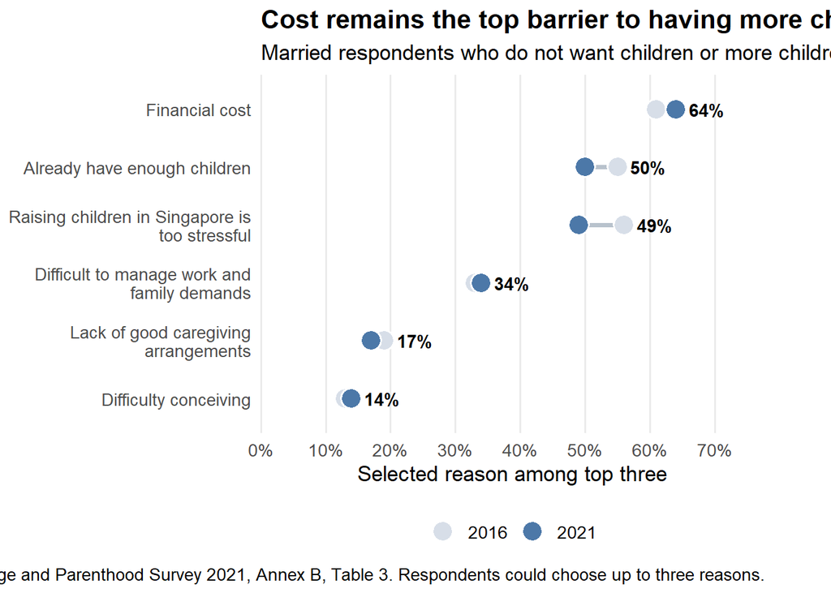

```r
survey_reasons_no_more_children <- tribble(
  ~reason, ~pct_2016, ~pct_2021,
  "Financial cost", 61, 64,
  "Already have enough children", 55, 50,
  "Raising children in Singapore is too stressful", 56, 49,
  "Difficult to manage work and family demands", 33, 34,
  "Lack of good caregiving arrangements", 19, 17,
  "Difficulty conceiving", 13, 14
) |>
  mutate(
    reason_wrapped = stringr::str_wrap(reason, width = 34),
    reason_wrapped = factor(reason_wrapped, levels = reason_wrapped[order(pct_2021)]),
    label_x = pmax(pct_2016, pct_2021) + 2,
    label_2021 = paste0(pct_2021, "%")
  )

survey_reasons_long <- survey_reasons_no_more_children |>
  select(reason_wrapped, pct_2016, pct_2021) |>
  pivot_longer(
    cols = c(pct_2016, pct_2021),
    names_to = "year",
    values_to = "pct"
  ) |>
  mutate(
    year = recode(year, pct_2016 = "2016", pct_2021 = "2021"),
    year = factor(year, levels = c("2016", "2021"))
  )

ggplot(survey_reasons_no_more_children, aes(y = reason_wrapped)) +
  geom_segment(
    aes(x = pct_2016, xend = pct_2021, yend = reason_wrapped),
    linewidth = 1.4,
    colour = "#B8C2CC"
  ) +
  geom_point(
    data = survey_reasons_long,
    aes(x = pct, fill = year),
    shape = 21,
    size = 5.5,
    colour = "white",
    stroke = 0.8
  ) +
  geom_text(
    aes(x = label_x, label = label_2021),
    hjust = 0,
    size = 3.8,
    fontface = "bold"
  ) +
  scale_x_continuous(
    labels = scales::label_percent(scale = 1),
    breaks = seq(0, 70, 10),
    expand = expansion(mult = c(0, 0.08))
  ) +
  scale_fill_manual(
    values = c("2016" = "#D7DEE8", "2021" = "#4C78A8")
  ) +
  coord_cartesian(xlim = c(0, 72), clip = "off") +
  labs(
    title = "Cost remains the top barrier to having more children",
    subtitle = "Married respondents who do not want children or more children. Labels show 2021 values.",
    x = "Selected reason among top three",
    y = NULL,
    fill = NULL,
    caption = "Source: Marriage and Parenthood Survey 2021, Annex B, Table 3. Respondents could choose up to three reasons."
  ) +
  theme_minimal(base_size = 13) +
  theme(
    legend.position = "bottom",
    panel.grid.major.y = element_blank(),
    panel.grid.minor = element_blank(),
    plot.title = element_text(face = "bold"),
    plot.margin = margin(5.5, 40, 5.5, 5.5)
  )
```

### Detailed analysis for understanding

- This insight is about family size after marriage, not only whether people are single or whether childbirth is delayed.
- The family-size trend focuses on women aged 40 to 49 because most have either completed or nearly completed childbearing. This makes the chart more suitable for discussing completed family size.
- In earlier years, larger families were more common among ever-married women aged 40 to 49.
- Over time, the share with no children increases and the share with one child also increases. These are related but should not be treated as the same outcome.
- The share with three or more children declines sharply, showing that larger families have become much less common.
- The survey plot adds an explanation layer. Among married respondents who did not want children or more children, the most common reasons in 2021 were financial cost, already having enough children, stress from raising children in Singapore, and difficulty managing work and family demands.
- This supports a stronger version of the fertility story: Singapore’s decline is not only caused by fewer people starting families. Even among ever-married women, family size has become smaller, and survey evidence suggests practical constraints may make additional children harder.
- This connects back to Insight 2. If marriage and first birth happen later, couples may have less time, energy, or financial capacity to have a second or third child.
- Main interpretation: persistent low fertility is partly a family-size issue. It is not only “nobody having children”; it is also more one-child families, fewer larger families, and practical barriers to having additional children.

## 8. Insight 4: childbearing has shifted about four and a half years later

### Purpose of this analysis

The age-specific fertility heatmap in Insight 2 shows that childbearing has shifted towards older age groups, but it does so qualitatively. This section converts that observation into two measured quantities.

The **mean age of childbearing (MAC)** is the average maternal age implied by a given year’s fertility schedule, weighting each age band midpoint by its age-specific fertility rate:

$$\text{MAC}_t = \frac{\sum_a m_a \cdot \text{ASFR}_{a,t}}{\sum_a \text{ASFR}_{a,t}}$$

where $m_a$ is the midpoint of age band $a$. MAC is a period measure rather than a cohort measure. It describes the timing implied by one year’s rates, not the completed experience of any real group of women.

The second measure is the share of total fertility contributed by women aged 30 and over. It is more readily interpreted by a general audience than MAC and produces a single crossover year that can be annotated directly on the chart.

```r
timing_measures <- asfr_complete |>
  group_by(year) |>
  summarise(
    total_asfr    = sum(asfr),
    mac           = sum(midpoint * asfr) / sum(asfr),
    share_30_plus = sum(asfr[age_group %in% c("30-34 Years", "35-39 Years",
                                              "40-44 Years", "45-49 Years")]) / sum(asfr) * 100,
    .groups = "drop"
  ) |>
  filter(total_asfr > 0)

# Year in which women aged 30 and over first contributed more than half of total fertility
crossover_year <- timing_measures |>
  filter(share_30_plus > 50) |>
  slice_min(year, n = 1) |>
  pull(year)

crossover_year
```

```
[1] 2001
```

```r
timing_measures |>
  filter(year %in% c(1960, 1970, 1980, 1990, 2000, 2010, 2020, 2025)) |>
  mutate(across(c(mac, share_30_plus), ~ round(.x, 1))) |>
  select(year, mac, share_30_plus)
```

```
# A tibble: 8 × 3
   year   mac share_30_plus
  <int> <dbl>         <dbl>
1  1960  29.4          44.1
2  1970  28.9          39
3  1980  28.2          33.5
4  1990  29.5          44.5
5  2000  30            49.7
6  2010  30.9          58.3
7  2020  32.1          68.3
8  2025  32.7          72.3
```

### Plot 4A: mean age of childbearing and the share of fertility from women aged 30 and over

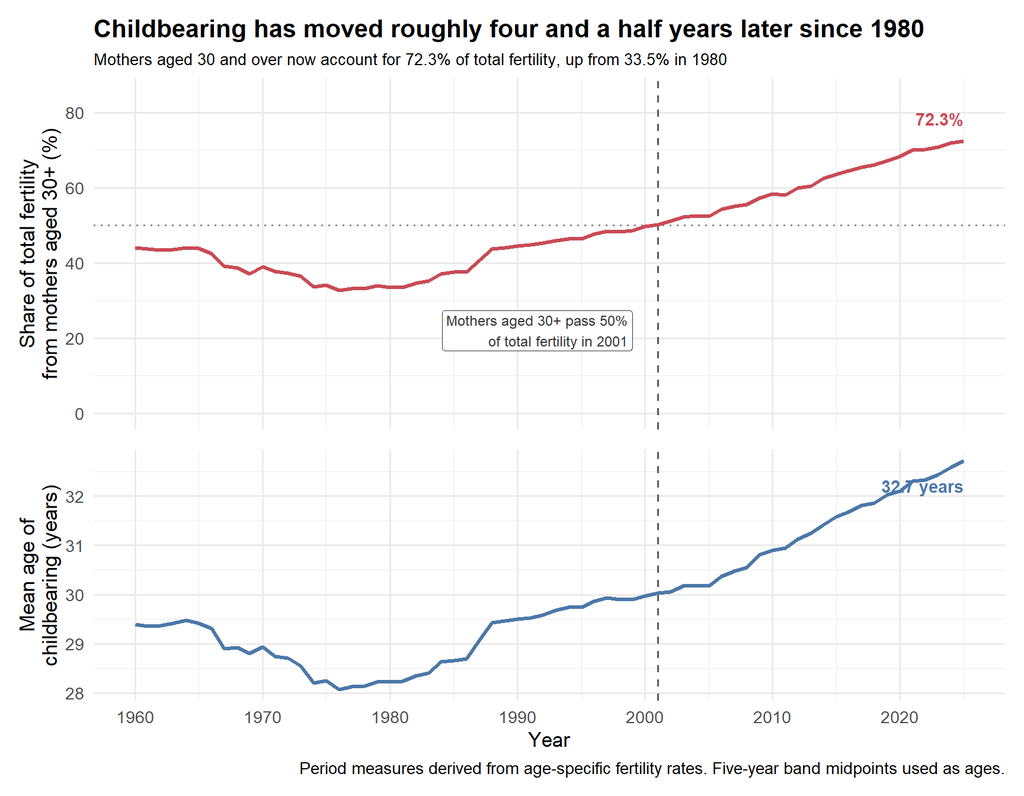

```r
timing_latest <- timing_measures |> filter(year == max(year))

panel_share <- ggplot(timing_measures, aes(x = year, y = share_30_plus)) +
  geom_hline(yintercept = 50, linetype = "dotted", colour = "grey55") +
  geom_vline(xintercept = crossover_year, linetype = "dashed", colour = "grey35") +
  geom_line(colour = "#C94B55", linewidth = 1.2) +
  annotate(
    "label",
    x = crossover_year - 2, y = 22,
    label = paste0("Mothers aged 30+ pass 50%\nof total fertility in ", crossover_year),
    size = 3.2, hjust = 1, label.size = 0, fill = "white", colour = "grey20"
  ) +
  annotate(
    "text",
    x = timing_latest$year, y = timing_latest$share_30_plus + 6,
    label = paste0(round(timing_latest$share_30_plus, 1), "%"),
    hjust = 1, fontface = "bold", size = 3.8, colour = "#C94B55"
  ) +
  scale_x_continuous(breaks = seq(1960, 2025, 10)) +
  scale_y_continuous(limits = c(0, 85)) +
  labs(
    title = "Childbearing has moved roughly four and a half years later since 1980",
    subtitle = "Mothers aged 30 and over now account for 72.3% of total fertility, up from 33.5% in 1980",
    x = NULL,
    y = "Share of total fertility\nfrom mothers aged 30+ (%)"
  ) +
  theme_minimal(base_size = 13) +
  theme(
    plot.title = element_text(face = "bold"),
    plot.subtitle = element_text(size = 10),
    axis.text.x = element_blank()
  )

panel_mac <- ggplot(timing_measures, aes(x = year, y = mac)) +
  geom_vline(xintercept = crossover_year, linetype = "dashed", colour = "grey35") +
  geom_line(colour = "#4C78A8", linewidth = 1.2) +
  annotate(
    "text",
    x = timing_latest$year, y = timing_latest$mac - 0.5,
    label = paste0(round(timing_latest$mac, 1), " years"),
    hjust = 1, fontface = "bold", size = 3.8, colour = "#4C78A8"
  ) +
  scale_x_continuous(breaks = seq(1960, 2025, 10)) +
  labs(
    x = "Year",
    y = "Mean age of\nchildbearing (years)",
    caption = "Period measures derived from age-specific fertility rates. Five-year band midpoints used as ages."
  ) +
  theme_minimal(base_size = 13)

panel_share / panel_mac + plot_layout(heights = c(1.4, 1))
```

### Findings

The mean age of childbearing declined through the 1960s and early 1970s, reaching a series minimum of 28.1 years in 1976. It has risen almost continuously since, reaching 29.5 in 1990, 30.9 in 2010 and 32.7 in 2025. The turning point matters for the project’s argument: the delay in childbearing is a post-1980 development, distinct from the original fertility transition that preceded it.

The share of fertility contributed by mothers aged 30 and over followed the same pattern. It stood at 33.5 per cent in 1980, crossed 50 per cent for the first time in 2001, and reached 72.3 per cent in 2025. Fertility in Singapore is now overwhelmingly concentrated among women in their thirties.

Taken together, the two measures indicate that childbearing has shifted approximately four and a half years later since 1980. This is consequential rather than merely descriptive. A later start compresses the interval available for second and third births, which connects this finding directly to the family-size results in Insight 3.

**ImportantInterpretation limits**

**These are period measures, not cohort measures.** They describe the timing implied by a single year’s fertility rates. Where women are steadily postponing births, period MAC rises and period TFR is temporarily depressed even if completed family size falls by less. This is known as the tempo effect. It means the TFR figures reported throughout this project understate completed family size to an unknown degree, and it is the reason this insight is presented alongside the completed family size evidence in Insight 3 rather than on its own.

**Age band midpoints are an approximation.** MAC is computed from five-year bands using midpoints rather than single years of age. Within-band distributions are not uniform, so the level of MAC carries a small bias. The trend over time is unaffected, and only the trend is used in the interpretation above.

**The 45 to 49 band is unavailable before 1980** and is treated as zero. The validation check in Section 3b confirms this produces a change of 0.002 years across the 1979 to 1980 boundary, which is negligible against normal year-to-year movement.

## 9. Insight 5: four fifths of the decline since 1990 comes from women under 30

### Purpose of this analysis

Insight 4 establishes that childbearing has moved later. This section quantifies how much each maternal age group contributed to the fall in TFR, and tests whether the increase in fertility at older ages is large enough to offset the decline at younger ages.

Because $\text{TFR} = 5 \sum_a \text{ASFR}_a / 1000$, the change in TFR decomposes exactly into additive contributions by age group:

$$\Delta \text{TFR} = \sum_a \frac{5 \cdot \Delta \text{ASFR}_a}{1000}$$

No model is fitted and no assumptions are required. The contributions sum to the total change by construction, which is what makes a waterfall chart the appropriate representation.

The base year is 1990. TFR had already stabilised near 1.8 by that point, so the comparison isolates the modern decline rather than the original demographic transition of the 1960s and 1970s.

```r
base_year    <- 1990
compare_year <- 2025

tfr_decomposition <- asfr_complete |>
  filter(year %in% c(base_year, compare_year)) |>
  select(year, age_group, asfr) |>
  pivot_wider(names_from = year, values_from = asfr, names_prefix = "asfr_") |>
  mutate(
    asfr_change  = .data[[paste0("asfr_", compare_year)]] - .data[[paste0("asfr_", base_year)]],
    contribution = asfr_change * 5 / 1000
  ) |>
  arrange(age_group)

start_tfr <- tfr_annual |> filter(year == base_year)    |> pull(tfr)
end_tfr   <- tfr_annual |> filter(year == compare_year) |> pull(tfr)

# Validation: contributions must sum to the observed change (small residual from
# rounding in the published TFR is expected).
tibble(
  sum_of_contributions = sum(tfr_decomposition$contribution),
  published_change     = end_tfr - start_tfr,
  residual             = sum(tfr_decomposition$contribution) - (end_tfr - start_tfr)
)
```

```
# A tibble: 1 × 3
  sum_of_contributions published_change residual
                 <dbl>            <dbl>    <dbl>
1               -0.955            -0.96  0.00500
```

```r
# Share of the total decline coming from women under 30
tfr_decomposition |>
  mutate(under_30 = age_group %in% c("15-19 Years", "20-24 Years", "25-29 Years")) |>
  group_by(under_30) |>
  summarise(contribution = sum(contribution), .groups = "drop") |>
  mutate(share_of_total_change = contribution / sum(contribution) * 100)
```

```
# A tibble: 2 × 3
  under_30 contribution share_of_total_change
  <lgl>           <dbl>                 <dbl>
1 FALSE          -0.181                  19.0
2 TRUE           -0.774                  81.0
```

```r
tfr_decomposition
```

```
# A tibble: 7 × 5
  age_group   asfr_1990 asfr_2025 asfr_change contribution
  <fct>           <dbl>     <dbl>       <dbl>        <dbl>
1 15-19 Years       8.3       1.3       -7        -0.035
2 20-24 Years      58.7       8.7      -50        -0.25
3 25-29 Years     136        38.3      -97.7      -0.488
4 30-34 Years     111.       70        -40.8      -0.204
5 35-39 Years      44.3      46.2        1.90      0.00950
6 40-44 Years       7.4       9.6        2.2       0.011
7 45-49 Years       0.1       0.5        0.4       0.002
```

### Plot 5A: waterfall of the TFR decline, 1990 to 2025

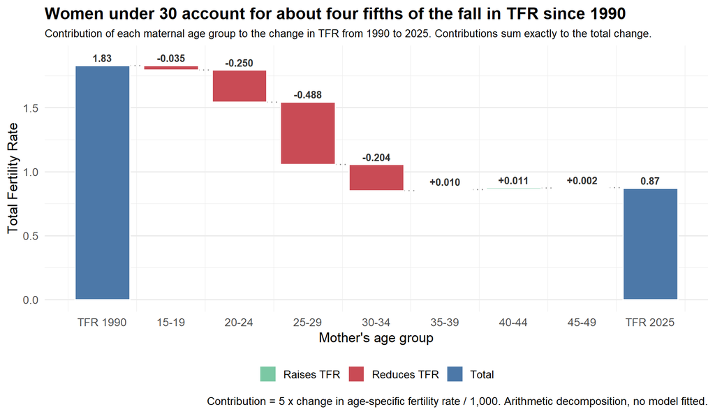

```r
steps <- tfr_decomposition |>
  mutate(
    cum_end   = start_tfr + cumsum(contribution),
    cum_start = lag(cum_end, default = start_tfr),
    label     = as.character(age_group),
    type      = if_else(contribution < 0, "Reduces TFR", "Raises TFR")
  )

waterfall_bars <- bind_rows(
  tibble(label = paste0("TFR ", base_year),
         ymin = 0, ymax = start_tfr, type = "Total", contribution = NA_real_),
  steps |> transmute(label,
                     ymin = pmin(cum_start, cum_end),
                     ymax = pmax(cum_start, cum_end),
                     type, contribution),
  tibble(label = paste0("TFR ", compare_year),
         ymin = 0, ymax = end_tfr, type = "Total", contribution = NA_real_)
) |>
  mutate(
    index = row_number(),
    label = factor(label, levels = label),
    value_label = if_else(
      is.na(contribution),
      sprintf("%.2f", ymax),
      paste0(if_else(contribution >= 0, "+", ""), sprintf("%.3f", contribution))
    ),
    label_y = ymax + 0.06
  )

# Dotted connectors carry the running total from one bar to the next
carry_levels <- c(start_tfr, steps$cum_end)
connector_df <- tibble(
  x    = seq_len(length(carry_levels)) ,
  xend = seq_len(length(carry_levels)) + 1,
  y    = carry_levels
)

ggplot(waterfall_bars) +
  geom_segment(
    data = connector_df,
    aes(x = x + 0.4, xend = xend - 0.4, y = y, yend = y),
    colour = "grey60", linetype = "dotted"
  ) +
  geom_rect(
    aes(xmin = index - 0.4, xmax = index + 0.4, ymin = ymin, ymax = ymax, fill = type),
    colour = "white"
  ) +
  geom_text(
    aes(x = index, y = label_y, label = value_label),
    size = 3.4, fontface = "bold", colour = "grey20"
  ) +
  scale_x_continuous(
    breaks = waterfall_bars$index,
    labels = str_replace(as.character(waterfall_bars$label), " Years", "")
  ) +
  scale_fill_manual(
    values = c("Total" = "#4C78A8", "Reduces TFR" = "#C94B55", "Raises TFR" = "#7BC8A4")
  ) +
  labs(
    title = "Women under 30 account for about four fifths of the fall in TFR since 1990",
    subtitle = paste0("Contribution of each maternal age group to the change in TFR from ",
                      base_year, " to ", compare_year, ". Contributions sum exactly to the total change."),
    x = "Mother's age group",
    y = "Total Fertility Rate",
    fill = NULL,
    caption = "Contribution = 5 x change in age-specific fertility rate / 1,000. Arithmetic decomposition, no model fitted."
  ) +
  theme_minimal(base_size = 13) +
  theme(
    legend.position = "bottom",
    panel.grid.major.x = element_blank(),
    plot.title = element_text(face = "bold"),
    plot.subtitle = element_text(size = 10)
  )
```

### Findings

TFR fell by 0.96 between 1990 and 2025, from 1.83 to 0.87.

The 25 to 29 age group alone contributes -0.488, roughly half of the entire decline. The 20 to 24 group contributes -0.250 and the 30 to 34 group -0.204. Teenage fertility, already low in 1990, contributes only -0.035.

The 35 to 39, 40 to 44 and 45 to 49 groups together contribute +0.023. Fertility at older ages has risen, but the gain is roughly one thirtieth of the size of the loss below age 30.

Combined, women under 30 account for 81.0 per cent of the total decline.

The interpretation is that postponed births are not being recovered. If the shift observed in Insight 4 were purely a matter of timing, losses below age 30 would be offset by comparable gains after 35. They are not. Births are being delayed and then largely forgone, which is why a change in timing translates into a sustained fall in the rate rather than a temporary dip.

**ImportantRobustness and limits**

**Single-year comparison.** The decomposition compares two individual years. Repeating it with three-year averages centred on 1990 and 2024 gives a total change of -0.834 and an under-30 share of 86.2 per cent, so the finding strengthens rather than weakens under averaging. The 81 per cent figure quoted above is therefore the conservative estimate.

**Zodiac effects.** Singapore birth counts respond measurably to the Chinese zodiac cycle, with Dragon years elevated and Tiger years depressed. Both 1990 and 2025 are ordinary years in this respect, but the averaged version above provides additional protection against this.

**Residual from rounding.** Contributions sum to -0.955 against a published change of -0.960. The residual of 0.005 arises from rounding in the published TFR series and is reported in the validation output above.

**Composition, not causation.** This is an accounting identity. It shows where the decline occurred, not why. It cannot distinguish a woman who never had children from one who had her first child at 34 rather than 27.

## 10. Insight 6: the decline is not uniform across ethnic groups

### Purpose of this analysis

All residents of Singapore are subject to the same national fertility policy, the same public housing system and the same labour market. If policy were the dominant driver of fertility, broadly similar outcomes across resident groups would be expected. The data does not show this.

This section examines total fertility rates disaggregated by the three main resident ethnic groups from 1960 to 2025, together with the changing spread between them.

**ImportantHow this section should be read**

Ethnicity is used here as an official statistical category published by SingStat. It stands in for underlying differences in age at first marriage, educational attainment, household income, religious practice and household composition, none of which this project measures directly.

This analysis describes a statistical pattern in those categories. It makes no claim about the groups themselves and offers no explanation located in ethnicity as such. The appropriate follow-up would be to compare median age at first marriage and educational attainment across groups, which would test whether the divergence disappears once those factors are controlled for. That data is available from SingStat but falls outside the scope of this project.

```r
ethnic_tfr <- fertility_wide |>
  filter(data_series %in% c("Chinese", "Malays", "Indians")) |>
  to_long_years() |>
  transmute(
    year,
    ethnic_group = factor(data_series, levels = c("Malays", "Indians", "Chinese")),
    tfr = value
  ) |>
  filter(!is.na(tfr))

ethnic_tfr |>
  filter(year %in% c(1960, 1980, 1990, 2000, 2010, 2020, 2025)) |>
  pivot_wider(names_from = ethnic_group, values_from = tfr) |>
  left_join(tfr_annual |> rename(`All residents` = tfr), by = "year") |>
  mutate(`Malay minus Chinese gap` = round(Malays - Chinese, 2))
```

```
# A tibble: 7 × 6
   year Chinese Malays Indians `All residents` `Malay minus Chinese gap`
  <int>   <dbl>  <dbl>   <dbl>           <dbl>                     <dbl>
1  2025    0.71   1.53    0.92            0.87                      0.82
2  2020    0.94   1.82    0.96            1.1                       0.88
3  2010    1.02   1.65    1.13            1.15                      0.63
4  2000    1.43   2.54    1.59            1.6                       1.11
5  1990    1.65   2.69    1.89            1.83                      1.04
6  1980    1.73   2.2     2.03            1.82                      0.47
7  1960    5.62   6.42    7.37            5.76                      0.8
```

```r
# How far each group has fallen, indexed to 1980
ethnic_tfr |>
  filter(year %in% c(1980, 2025)) |>
  pivot_wider(names_from = year, values_from = tfr, names_prefix = "y") |>
  mutate(
    absolute_change = y2025 - y1980,
    percent_change  = (y2025 / y1980 - 1) * 100
  )
```

```
# A tibble: 3 × 5
  ethnic_group y2025 y1980 absolute_change percent_change
  <fct>        <dbl> <dbl>           <dbl>          <dbl>
1 Chinese       0.71  1.73           -1.02          -59.0
2 Malays        1.53  2.2            -0.67          -30.5
3 Indians       0.92  2.03           -1.11          -54.7
```

### Plot 6A: total fertility rate by ethnic group, 1960 to 2025

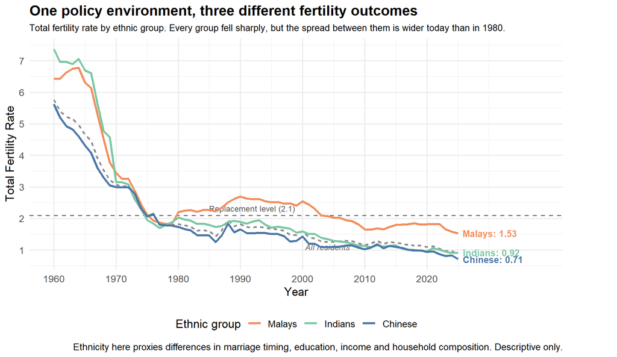

```r
ethnic_palette <- c(
  "Malays"  = "#F28E5C",
  "Indians" = "#7BC8A4",
  "Chinese" = "#4C78A8"
)

ethnic_latest <- ethnic_tfr |>
  filter(year == max(year)) |>
  mutate(label = paste0(ethnic_group, ": ", sprintf("%.2f", tfr)))

ggplot(ethnic_tfr, aes(x = year, y = tfr, colour = ethnic_group)) +
  geom_hline(yintercept = 2.1, linetype = "dashed", colour = "grey45") +
  annotate("text", x = 1985, y = 2.32, label = "Replacement level (2.1)",
           hjust = 0, size = 3.2, colour = "grey35") +
  geom_line(
    data = tfr_annual |> filter(!is.na(tfr)),
    aes(x = year, y = tfr), inherit.aes = FALSE,
    colour = "grey55", linewidth = 0.9, linetype = "22"
  ) +
  annotate("text", x = 2004, y = 1.10, label = "All residents",
           size = 3.2, colour = "grey40", fontface = "italic") +
  geom_line(linewidth = 1.2) +
  geom_text(
    data = ethnic_latest,
    aes(label = label),
    hjust = 0, nudge_x = 0.8, size = 3.5, fontface = "bold", show.legend = FALSE
  ) +
  scale_colour_manual(values = ethnic_palette) +
  scale_x_continuous(breaks = seq(1960, 2025, 10)) +
  scale_y_continuous(breaks = seq(0, 7, 1)) +
  coord_cartesian(xlim = c(1960, 2038), clip = "off") +
  labs(
    title = "One policy environment, three different fertility outcomes",
    subtitle = "Total fertility rate by ethnic group. Every group fell sharply, but the spread between them is wider today than in 1980.",
    x = "Year",
    y = "Total Fertility Rate",
    colour = "Ethnic group",
    caption = "Ethnicity here proxies differences in marriage timing, education, income and household composition. Descriptive only."
  ) +
  theme_minimal(base_size = 13) +
  theme(
    legend.position = "bottom",
    plot.title = element_text(face = "bold"),
    plot.subtitle = element_text(size = 10),
    plot.margin = margin(5.5, 60, 5.5, 5.5)
  )
```

### Plot 6B: the gap between the highest and lowest group

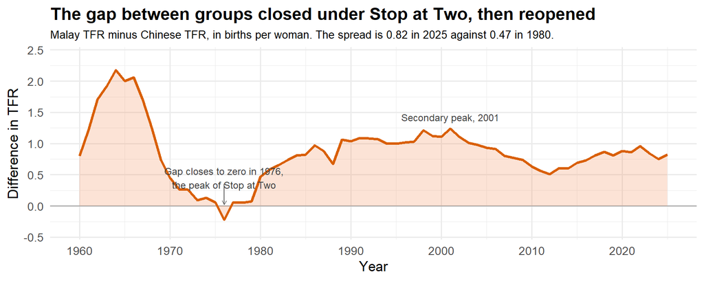

```r
ethnic_gap <- ethnic_tfr |>
  pivot_wider(names_from = ethnic_group, values_from = tfr) |>
  mutate(gap = Malays - Chinese) |>
  filter(!is.na(gap))

ggplot(ethnic_gap, aes(x = year, y = gap)) +
  geom_hline(yintercept = 0, colour = "grey70") +
  geom_area(fill = "#F28E5C", alpha = 0.25) +
  geom_line(colour = "#d95f02", linewidth = 1.2) +
  annotate("segment", x = 1976, xend = 1976, y = 0.35, yend = 0.02,
           colour = "grey40", linewidth = 0.4,
           arrow = arrow(length = unit(0.15, "cm"))) +
  annotate("text", x = 1976, y = 0.45,
           label = "Gap closes to zero in 1976,\nthe peak of Stop at Two",
           size = 3.1, colour = "grey25", hjust = 0.5) +
  annotate("text", x = 2001, y = 1.42,
           label = "Secondary peak, 2001",
           size = 3.1, colour = "grey25") +
  scale_x_continuous(breaks = seq(1960, 2025, 10)) +
  scale_y_continuous(limits = c(-0.4, 2.4)) +
  labs(
    title = "The gap between groups closed under Stop at Two, then reopened",
    subtitle = "Malay TFR minus Chinese TFR, in births per woman. The spread is 0.82 in 2025 against 0.47 in 1980.",
    x = "Year",
    y = "Difference in TFR"
  ) +
  theme_minimal(base_size = 13) +
  theme(plot.title = element_text(face = "bold"),
        plot.subtitle = element_text(size = 10))
```

### Findings

In 1980 the three groups recorded total fertility rates of 1.73 (Chinese), 2.03 (Indians) and 2.20 (Malays), a spread of 0.47 between highest and lowest. By 2025 the figures were 0.71, 0.92 and 1.53, a spread of 0.82. Every group fell substantially over the period, so this is not a case of one group being exempt from the national decline.

The relative falls differ sharply. Measured from 1980, Chinese fertility fell 59.0 per cent and Indian fertility 54.7 per cent, while Malay fertility fell 30.5 per cent. Chinese resident TFR now stands at 0.71, a level comparable to the lowest national rates recorded anywhere.

**ImportantLimits of this comparison**

**Group sizes differ substantially.** Chinese residents form the large majority of the resident population, so the all-resident TFR tracks the Chinese series closely by construction. The apparent agreement between the two lines in the chart is arithmetic, not evidence.

**Composition changes over time.** Immigration and naturalisation alter the composition of each resident group across the period. A shift in the educational or age profile within a group can move its TFR without any change in individual behaviour.

**The claim about international comparison requires a source.** The statement that Chinese resident TFR is comparable to the lowest national rates anywhere should be cited to a specific published figure, or removed. It is not supported by the datasets used here.

## 7. Recommended final insight package

Use three insight sections. Some insights use two plots because one plot alone does not fully explain the story.

### Insight 1: Policy shifts did not create a sustained fertility rebound

Use:

- TFR around major fertility policies
- Five-year before-vs-after policy dumbbell comparison

Core message:

- The anti-natalist Stop at Two policy aligns with continued fertility decline.
- The 1987 pro-natalist shift shows the clearest short-term improvement or stabilisation.
- Later pro-natalist policies do not show a large sustained rebound in TFR.
- This does not mean policy is irrelevant. It means policy is only one part of the fertility story.
- Use careful wording: policy timing aligns with changes in the TFR trend, but the chart does not prove causality.

### Insight 2: Delayed family formation sits alongside changing work and marriage patterns

Use:

- ASFR decade heatmap
- LFPR and singlehood bubble scatter

Core message:

- The ASFR heatmap shows that childbearing shifted from the 20s toward the 30s.
- Over the same period, Singapore moves toward higher female LFPR and higher female singlehood, while TFR becomes smaller.
- This supports the broader story that fertility decline happened alongside delayed family formation and changes in work and marriage patterns.
- Use careful wording: this is descriptive association, not proof that LFPR or singlehood directly caused fertility decline.

### Insight 3: Smaller family size makes low fertility harder to reverse

Use:

- Family-size trend among ever-married women aged 40 to 49
- Survey reasons for not wanting children or more children

Core message:

- Among ever-married women aged 40 to 49, both childlessness and one-child families have increased.
- The share with three or more children has declined.
- Survey evidence suggests financial cost, stress, and work-family demands are key barriers to having additional children.
- This supports the idea that Singapore’s fertility decline is not only about fewer people starting families. Even among women who marry, family size has become smaller, and practical constraints may limit progression to larger families.

### How to frame the “snowball” idea safely

The snowball idea is useful, but it should be worded carefully.

What is safe to say:

- Low fertility can become entrenched over time.
- Later marriage and later first births reduce the time window for having second or third children.
- Fewer births today also affect future population structure, because smaller cohorts eventually enter family-forming ages.
- This means recovery can become harder even if later policies encourage childbearing.

What not to overclaim:

- Do not say fewer babies directly causes TFR to fall later. TFR is a rate, while total births also depend on population size and age structure.
- Without female population-by-age data, we should present the snowball effect as interpretation, not as a measured result.

Better conclusion wording:

Singapore’s fertility decline appears to be an entrenched structural issue rather than a one-year shock. Policy changes matter, but the data suggests that delayed marriage, later childbearing, changing work patterns, and smaller family sizes make fertility harder to reverse once low fertility becomes established.

### Final recommendation

For the final presentation, use these supporting plots as three insight packages:

1. Policy package: TFR around major fertility policies and five-year before-vs-after comparison
2. Delayed family formation package: ASFR decade heatmap and LFPR/singlehood bubble scatter
3. Smaller family size package: family-size trend for ever-married women aged 40 to 49 and survey reasons for not wanting children or more children

Skip the recession event-window plot for the main analysis. Recessions can remain as light annotations in the main final visual, but they do not give the clearest explanation of the long-term decline.